# Innlevering 2

Innlevering 2 i Data Science 2021 - Maren Sognefest og Daniel Karstad

# Er det høyde som bestemmer inntekt?

Denne artikkelen skal ta for seg om det er en, og eventuelt hvilken, sammenheng det er mellom høyde og inntekt. Ved hjelp av flere analyser, skal vi bruke datasettet *heights* fra pakken *modelr* skal vi prøve å finne ut om det er en sammenheng. Kan det stemme at høye personer tjener mest?

I analyse-delen av artikkelen vil vi bruke ulike **plots** for å analysere spørsmålet, og komme frem til en konklusjon.

|  | income | height | weight | age | marital | sex | education | afqt |
| --- | --- | --- | --- | --- | --- | --- | --- | --- |
|  | Min. : 0.0 | Min. :52.0 | Min. : 76.0 | Min. :47.00 | single :1124 | male :3402 | Min. : 1.00 | Min. : 0.00 |
|  | 1st Qu.: 165.5 | 1st Qu.:64.0 | 1st Qu.:157.0 | 1st Qu.:49.00 | married :3806 | female:3604 | 1st Qu.:12.00 | 1st Qu.: 15.12 |
|  | Median : 29589.5 | Median :67.0 | Median :184.0 | Median :51.00 | separated: 366 | NA | Median :12.00 | Median : 36.76 |
|  | Mean : 41203.9 | Mean :67.1 | Mean :188.3 | Mean :51.33 | divorced :1549 | NA | Mean :13.22 | Mean : 41.21 |
|  | 3rd Qu.: 55000.0 | 3rd Qu.:70.0 | 3rd Qu.:212.0 | 3rd Qu.:53.00 | widowed : 161 | NA | 3rd Qu.:15.00 | 3rd Qu.: 65.24 |
|  | Max. :343830.0 | Max. :84.0 | Max. :524.0 | Max. :56.00 | NA | NA | Max. :20.00 | Max. :100.00 |
|  | NA | NA | NA’s :95 | NA | NA | NA | NA’s :10 | NA’s :262 |

Over er sammendraget av statistikken i datasettet “heights.” Man har kolonner med inntekt i dollar, høyde i tommer, vekt i pound, alder, sivilstatus, kjønn, utdannelse og score på Armed Forces Qualitication Test.

Under har vi kopiert datasettet “heights” og kalt det “hoyde.” Her har vi regnet dataen om til europeiske standarderer; vi bruker høyde i cm og vekt i kg, i tillegg til at inntekten er i norske kroner, at vi har laget en egen kolonne for BMI og at vi har laget en forenklet utgave av marital (married - not married). Det er også et sammendrag av dette under.

```r
hoyde <-   heights %>%
mutate(heights, hoyde_cm = height*2.54, #høyde i cm = hoyde i tommer * 2,54 fordi 1 tommer = 2,54 cm
       vekt_kg = weight/2.2, #vekt i kg = vekt i pound / 2.2 fordi 2,2 kg = 1 pound
       inntekt_nok = income*8.5,  #inntekt i nok = inntekt i dollar * 8,5 fordi 1 dollar = 8,5 kr
        married = factor(
          case_when(
            marital == 'married' ~ TRUE,
            TRUE ~ FALSE)
          )
       )
hoyde$bmi <- hoyde$vekt_kg/(hoyde$hoyde_cm/100)/(hoyde$hoyde_cm/100) #bmi = vekt i kg / (hoyde i m)^2
hoyde$weight <- NULL #fjerner vekt i pounds fra datasett
hoyde$height <- NULL #fjerner høyde i tommer fra datasett
hoyde$income <- NULL #fjerner inntekt i dollar fra datasett

knitr::kable(summary(hoyde[1:5]))
```

|  | age | marital | sex | education | afqt |
| --- | --- | --- | --- | --- | --- |
|  | Min. :47.00 | single :1124 | male :3402 | Min. : 1.00 | Min. : 0.00 |
|  | 1st Qu.:49.00 | married :3806 | female:3604 | 1st Qu.:12.00 | 1st Qu.: 15.12 |
|  | Median :51.00 | separated: 366 | NA | Median :12.00 | Median : 36.76 |
|  | Mean :51.33 | divorced :1549 | NA | Mean :13.22 | Mean : 41.21 |
|  | 3rd Qu.:53.00 | widowed : 161 | NA | 3rd Qu.:15.00 | 3rd Qu.: 65.24 |
|  | Max. :56.00 | NA | NA | Max. :20.00 | Max. :100.00 |
|  | NA | NA | NA | NA’s :10 | NA’s :262 |

```r
knitr::kable(summary(hoyde[6:10]), "pipe")
```

|  | hoyde_cm | vekt_kg | inntekt_nok | married | bmi |
| --- | --- | --- | --- | --- | --- |
|  | Min. :132.1 | Min. : 34.55 | Min. : 0 | FALSE:3200 | Min. :12.90 |
|  | 1st Qu.:162.6 | 1st Qu.: 71.36 | 1st Qu.: 1407 | TRUE :3806 | 1st Qu.:25.14 |
|  | Median :170.2 | Median : 83.64 | Median : 251511 | NA | Median :28.38 |
|  | Mean :170.4 | Mean : 85.59 | Mean : 350234 | NA | Mean :29.37 |
|  | 3rd Qu.:177.8 | 3rd Qu.: 96.36 | 3rd Qu.: 467500 | NA | 3rd Qu.:32.35 |
|  | Max. :213.4 | Max. :238.18 | Max. :2922555 | NA | Max. :75.15 |
|  | NA | NA’s :95 | NA | NA | NA’s :95 |

```r
NA
```

# EDA (vha. ggplot) av datasettet.

### Analyse med 1-variabel

Denne delen inneholder noen grafer med 1 variabel. Dette for å se om variablene er normalfordelt.

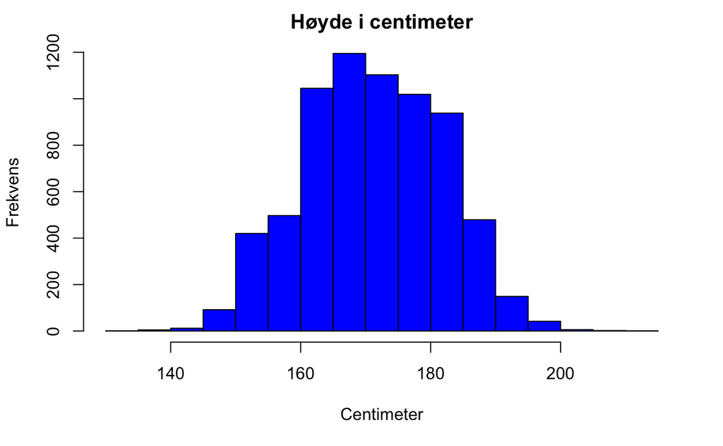

```
[1] 1740
```

Det er altå 1740 personer uten inntekt med i datasettet.

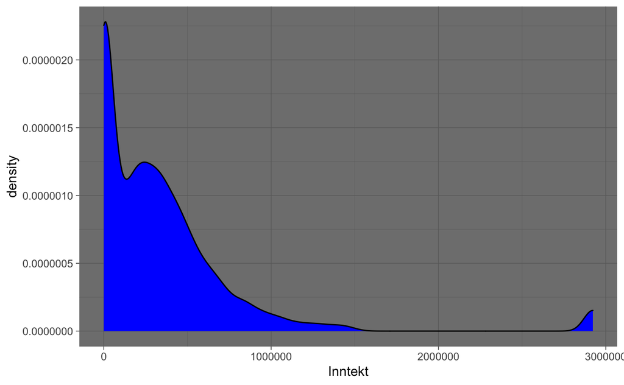

```r
Inntekt <- hoyde$inntekt_nok
ggplot(hoyde = Inntekt) + theme_dark() +
  geom_density(aes(x = Inntekt), fill = "blue")
```

Denne grafen illustrerer inntekt, og her ser man ved første øyekast at det ikke er normalfordelt. Dette fordi man har mange observasjoner tilnærmet 0, og hovedvekten er <500,000.00 NOK. I andre enden av skalaen, de med 2% høyest inntekt er illustrert ved et gjennomsnitt av lønnen. Derfor foreligger det ingen observasjoner mellom 1,600,000.00 NOK og 3,000,000.00 NOK.

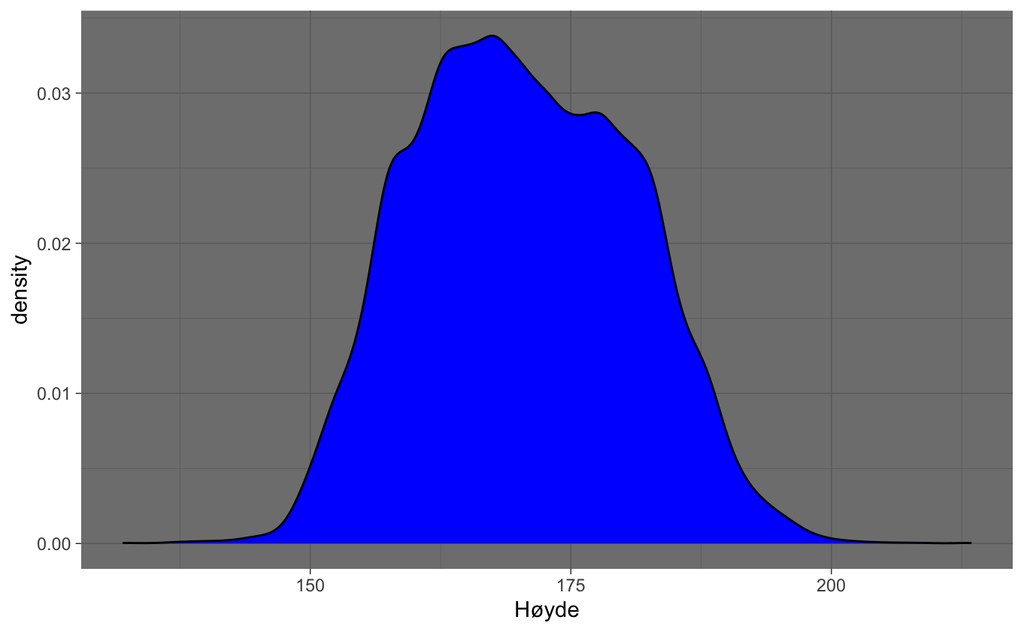

```r
Høyde <- hoyde$hoyde_cm
Inntekt <- hoyde$inntekt_nok
ggplot(hoyde = Høyde) + theme_dark() +
  geom_density(aes(x = Høyde), fill = "blue")
```

Ovenfor kan sees et density plot. Det vise hovedsaklig det samme som histogrammet, men man ser enklere tettheten av observasjonene her ved en jevn og fin kurve. Her ser man igjen, en tilnærmet normalfordeling.